# hw-02

## Exercise 2

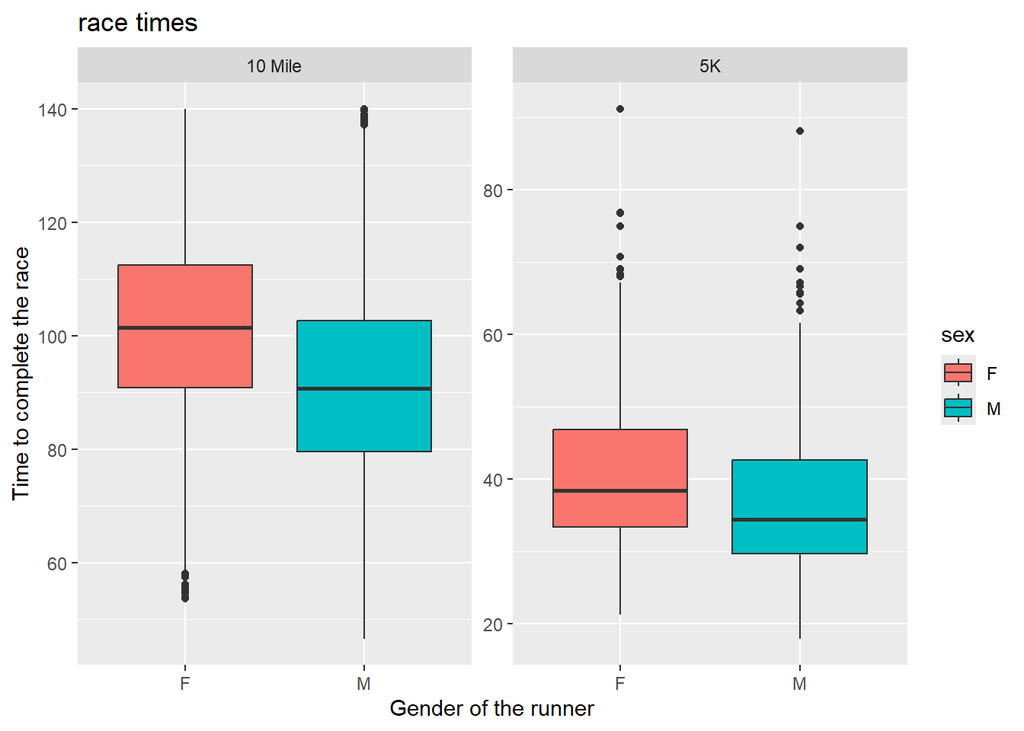

```r
# Write your code to answer exercise 2a here

run17 %>%
  mutate(tm = net_sec/60) %>%
  ggplot(mapping= aes(
           x = sex ,
           y = tm,
           fill = sex
         )) +
    geom_boxplot() +
    labs(
      x= "Gender of the runner",
      y= "Time to complete the race",
      title = "race times"
    )+
  facet_wrap(~ event, scales = "free_y")
```

*From the visualization we can see that for both the 10 mile event and 5k event the for females and males have similar IQR meaning the data is spread similarly for both sexes, however the median values for the female times are greater thus on average men finish faster.*

## Exercise 3

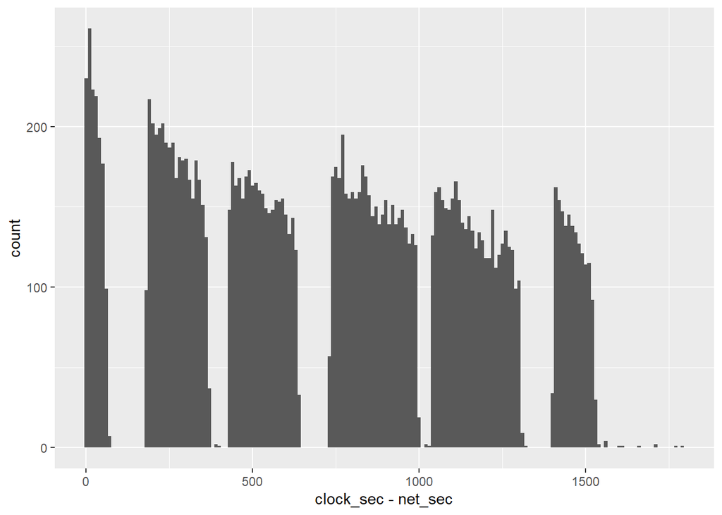

```r
# Write your code to answer exercise 3 here
ggplot(data = run17 %>% filter(event == "10 Mile"),
       mapping = aes(x = clock_sec - net_sec)) +
  geom_histogram(binwidth = 10)
```

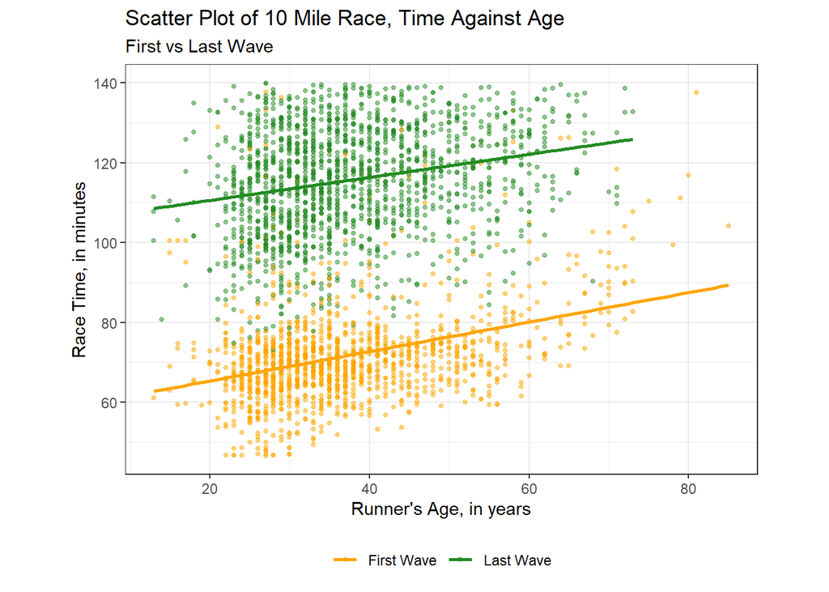

```r
first_wave <- run17 %>%
  filter(event == "10 Mile") %>%
  mutate(runners_per_wave = clock_sec - net_sec) %>%
  filter(runners_per_wave %in% (0:74))

run17 %>%
  filter(event == "10 Mile") %>%
  mutate(runners_per_wave = clock_sec - net_sec,
         waves = case_when(
           runners_per_wave %in% 0:74 ~ "First Wave",
           runners_per_wave %in% 1403:1792 ~ "Last Wave"
         )) %>%
  filter(waves == "First Wave"| waves == "Last Wave") %>%
  filter(!is.na(waves)) %>%
  ggplot(aes(x = age, y = net_sec / 60, color = waves)) +
  geom_point(alpha = 0.5, size = 1) +
  geom_smooth(method = "lm", se = FALSE) +
  scale_color_manual(values = c("First Wave" = "orange", "Last Wave" = "forestgreen")) +
  theme_bw() +
  labs(title = "Scatter Plot of 10 Mile Race, Time Against Age",
       subtitle = "First vs Last Wave",
       x = "Runner's Age, in years",
       y = "Race Time, in minutes",
       color = NULL) +
  theme(
    legend.position = "bottom",
    legend.direction = "horizontal",
  ) +
  coord_fixed(ratio = 0.5)
```

## Exercise 4

#### Example of a good data visualisation

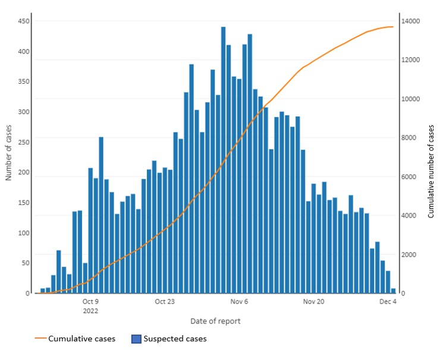

**who**, “**who**” [Online]. Available at: **https://www.who.int/emergencies/disease-outbreak-news/item/2022-DON427** (Accessed: **31 10 2024**)

The above image presents a good data visualisation because:

- Distinct colours for different data
- Chooses the correct graph for the data; line for data that has a trend and barchart for data without a trend

#### Example of a bad data visualisation

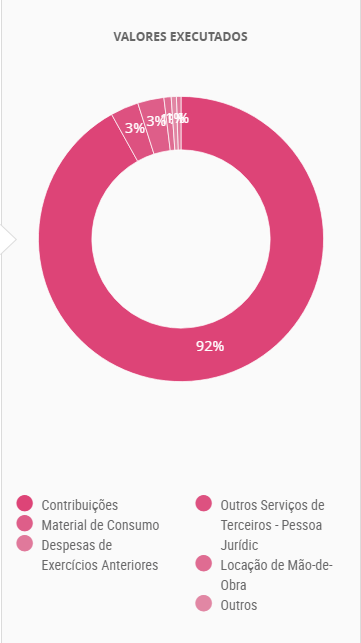

**WTFViz**, “**viz**” [Online]. Available at: **https://viz.wtf/** (Accessed: **31 10 2024**)

The above image presents a bad data visualisation because:

- Non-distinct colours are a terrible choice for representing categorical data
- Illegible lables that overlap for the percentages of each section of pie chart